# From GWAS Summary Statistics to Candidate Causal Genes: A Reproducible Post-GWAS Pipeline for Circulating Metabolic Traits in European-Ancestry Biobanks

Meta-analysis, heritability, fine-mapping, colocalization, and Mendelian randomization for LDL cholesterol, branched-chain amino acids, glucose, and lactate

Khushi Goda

2026-07-27

> **GitHub Repository:** https://github.com/khushigoda/variantbench

# 1 Overview & method choices

> **Reproducibility.** This document is the R Markdown source `workflow/scripts/08_report.Rmd`, knitted by the Snakemake `report` rule. Every number, table, and figure below is generated at knit time by reading the pipeline’s output files in `results/` — nothing is hand-entered or pasted. Re-running the pipeline and re-knitting regenerates this report end to end, so the report cannot drift from the analysis it describes.

> **Scope of this knit.** This version reports the **completed steps: meta-analysis, LDSC, lead-variant definition, and fine-mapping + coding annotation (Steps 1–4)**, each followed by a multiple-choice question testing the biological reasoning behind that step. Steps 1–2 run across all four traits; Steps 3–4 are shown for **LDL_C**, the positive-control trait whose 11 canonical effector loci let the out-of-sample-LD behaviour be inspected locus by locus. Colocalization with molecular QTLs (Step 5) and Mendelian randomization — genome-wide and drug-target *cis*-MR (Steps 6–7) — are also shown for **LDL_C**, each step with its own MCQ, testing the causal effect of LDL-C on coronary artery disease.

This report follows four circulating metabolic traits — **LDL cholesterol (LDL_C)**, **total branched-chain amino acids (BCAA)**, **glucose**, and **lactate** — from published GWAS summary statistics through a standard post-GWAS causal-inference chain: cross-cohort meta-analysis, heritability and genetic correlation (LDSC), lead-variant definition, statistical fine-mapping, colocalization with gene expression, and Mendelian randomization against two cardiometabolic diseases. The analysis is **European-ancestry throughout** (EstBB + UKBB_EUR exposures, EUR-matched CAD/T2D outcomes, 1000G EUR LD reference), and **no individual-level genotype data is used** — every step operates on summary statistics plus a public LD reference.

**Data provenance.** All exposure summary statistics come from Tambets *et al.*[^1], a GWAS meta-analysis of 249 circulating metabolic traits in the **Estonian Biobank (EstBB)** and the **UK Biobank (UKBB)**, retrieved as GWAS-SSF-formatted files from the **NHGRI-EBI GWAS Catalog**. For each metabolite the pipeline uses the two per-cohort European releases (EstBB and UKBB_EUR) as meta-analysis inputs and the authors’ own published European meta-analysis as the Step-1 validation target. The **coronary artery disease (CAD)** outcome used downstream is the European-ancestry release of Aragam *et al.*[^2] (GWAS Catalog `GCST90132314`). **Every file is on GRCh38**: the metabolite and CAD statistics are served already harmonised to GRCh38 by the GWAS Catalog, so no coordinate liftover is applied to them.

The four exposures are chosen as a **gradient of causal-prior strength**, so the pipeline is shown to *discriminate* rather than merely run. **LDL_C is the canonical positive control**: the causal LDL→CAD relationship is established by the totality of genetic, epidemiologic, and randomized-trial evidence — including RCTs of statins (*HMGCR*), PCSK9 inhibitors (*PCSK9*), and ezetimibe (*NPC1L1*)[^3] — so recovering a positive *cis*-MR at these drug-target genes is the strongest validation of the whole arc. **BCAA** (anchored by the catabolic regulators *PPM1K* / *BCKDK*), whose causal role in type 2 diabetes has itself been supported by Mendelian randomization[^4], and **glucose** (anchored by *GCK* / *GCKR* / *G6PC2* / *SLC30A8*) are further positive controls for the diabetes axis, both tested against T2D. **Lactate is the contrast**: different biology (glycolysis), a weaker causal prior, and a notable locus at *GP6* (platelet collagen receptor) biologically distant from a metabolic-disease mechanism — a test of whether the methods correctly report a *less* compelling causal picture. Together the four exposures span loci across the genome and several distinct pathways, so the pipeline can be judged on whether it **discriminates** strong causal signals from weak ones.

**Scope and resource constraints, stated up front.** Because of finite compute and a fixed time budget, the analysis was **not** run across the full planned set of metabolites — the report focuses on LDL_C (with the other three traits carried through the early steps) rather than the paper’s full metabolite panel. This is a scoping decision, not an architectural limit: the pipeline is **config-driven** (`config/config.yaml`), so adding a metabolite is a one-line accession entry and the same Snakemake rules then run end to end for it — the design scales to any desired number of traits, and the restriction here is purely one of available resources. For the same reason, some **tools and methodological choices deliberately diverge from the published study** where a lighter or more self-contained alternative fit the resource envelope (these substitutions are flagged in the affected sections). All work runs on a single workstation-class machine (**8-core CPU, 8 GiB RAM, no GPU**); memory in particular drives several of these choices.

**The LD reference is out-of-sample.** Fine-mapping and MR instrument pruning use a 1000 Genomes EUR panel, **not** the in-sample UKBB LD the reference paper used. Out-of-sample LD can miscalibrate SuSiE credible sets and mis-prune instruments; this is an accepted tractability tradeoff, flagged here and again in each affected section. With LDL_C selected as the metabolite of interest, **CAD is the appropriate disease outcome** for the downstream colocalization and MR, so T2D is left out of the reported arc.

# 2 Meta-analysis (Step 1)

This step combines the two European cohorts — EstBB and UKBB_EUR — into a single genome-wide association table for each metabolite using **inverse-variance-weighted, fixed-effect meta-analysis**. The main steps are: each cohort’s summary statistics are matched variant by variant on chromosome, position, and both alleles (a **no-flip join**, so only identically oriented effect alleles are combined and any strand or allele mismatch is left uncombined rather than silently mis-merged); every variant is weighted by the inverse of its squared standard error, so more precisely estimated cohorts contribute more; the pooled effect is the weighted mean of the per-cohort betas, with a pooled standard error of √(1/Σw); and effect-allele frequency and sample size are carried through, with a signed *z*-statistic, two-sided *p*-value, and a Cochran’s-*Q* heterogeneity test computed per variant. Crucially, **every union variant is kept** — the table is not restricted to a HapMap3 or well-imputed subset — because the downstream steps (lead-variant definition, fine-mapping, MR) need the full genome-wide signal. The whole meta is run **one chromosome at a time and written incrementally**, so the full ~100M-variant table is produced without ever holding more than a single chromosome in memory — the design choice that lets a genome-wide meta run on an 8 GiB machine. Finally, the result is **validated against the authors’ published `meta_EUR`**: our pooled betas are regressed on theirs, and the OLS slope and Pearson *r* should both sit at ≈1 if the allele harmonization and inverse-variance weighting are correct.

| metab | pearson_r | slope | n_variants | n_compared | n_both | n_estbb_only | n_ukbb_only |
| --- | --- | --- | --- | --- | --- | --- | --- |
| BCAA | 0.999999999999989 | 0.999999999987551 | 103927003 | 103927003 | 17976457 | 8197137 | 77753409 |
| Lactate | 0.999999999999991 | 1.00000000001978 | 103927003 | 103927003 | 17976457 | 8197137 | 77753409 |
| LDL_C | 0.999999999999986 | 1.00000000002351 | 103927003 | 103927003 | 17976457 | 8197137 | 77753409 |
| Glucose | 1 | 1.00000000000254 | 103927003 | 103927003 | 17976457 | 8197137 | 77753409 |

The table reads out that validation. `pearson_r` and `slope` sit at machine precision to 1, meaning the pooled effect sizes reproduce the authors’ published meta exactly across all union variants, while the overlap columns (`n_both`, `n_estbb_only`, `n_ukbb_only`) confirm the meta genuinely combined both cohorts rather than defaulting to whichever one was present. Together these confirm that the summary-statistic pre-processing was accurate and the genome-wide table is ready for the downstream steps.

**How this compares to the source manuscript.** The reproduced European meta-analysis pools the same two cohorts the authors describe — EstBB (n ≈ 185,352) and UKBB_EUR (n ≈ 413,897) — into a `meta_EUR` of **n = 599,249**, matching the published sample size exactly. The validation scatter here plays the same role as the manuscript’s Supplementary Fig. 2, which regresses shared lead-variant betas from their `meta_EUR` against a prior published analysis (Karjalainen et al.) and reports near-perfect concordance where the samples overlap. The comparison differs in one honest respect: the manuscript benchmarks against an *external* study with only partial sample overlap, so their agreement is high but sub-unity; this replication benchmarks against the authors’ *own* published `meta_EUR` over the identical cohorts, so `r` and slope sit at machine precision to 1 — a reproduction check rather than a cross-study replication. Both confirm the same thing: allele harmonisation and inverse-variance weighting recover effect sizes that agree with the reference.

**Validation — reproduced meta (`meta_rep`) against the original published meta (`meta_og`), per metabolite:**

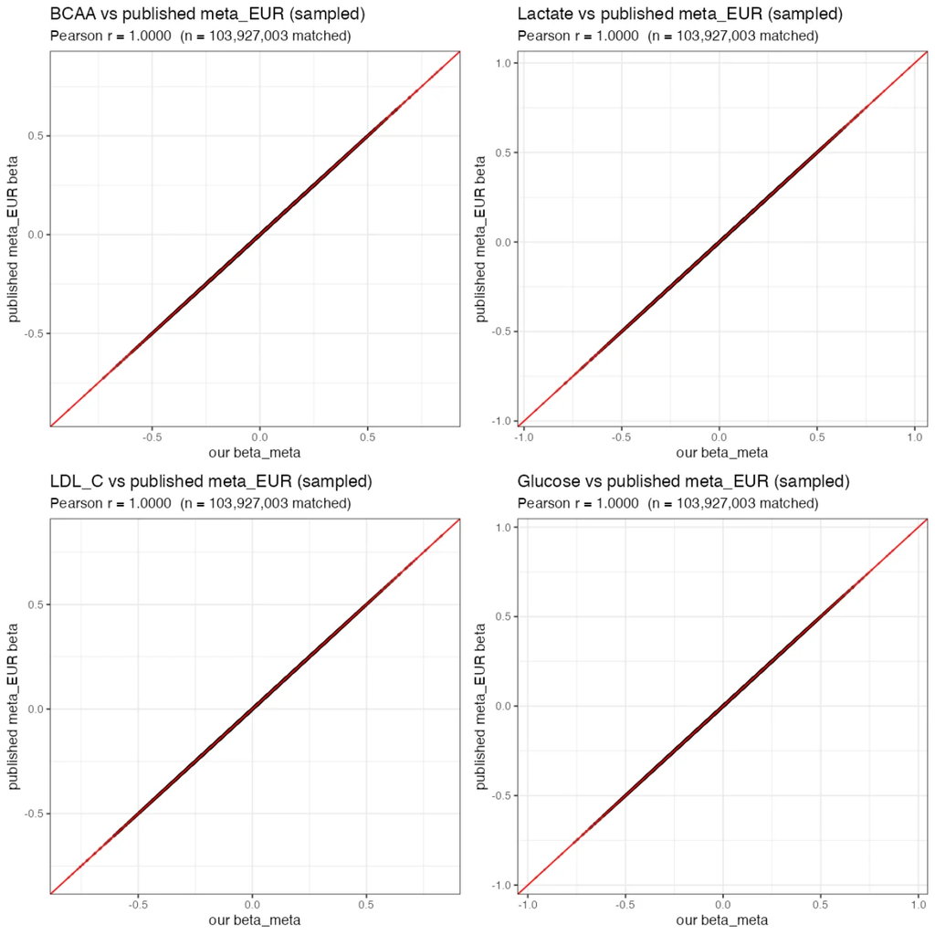

**Cross-cohort concordance — EstBB vs UKBB effect sizes, per metabolite:**

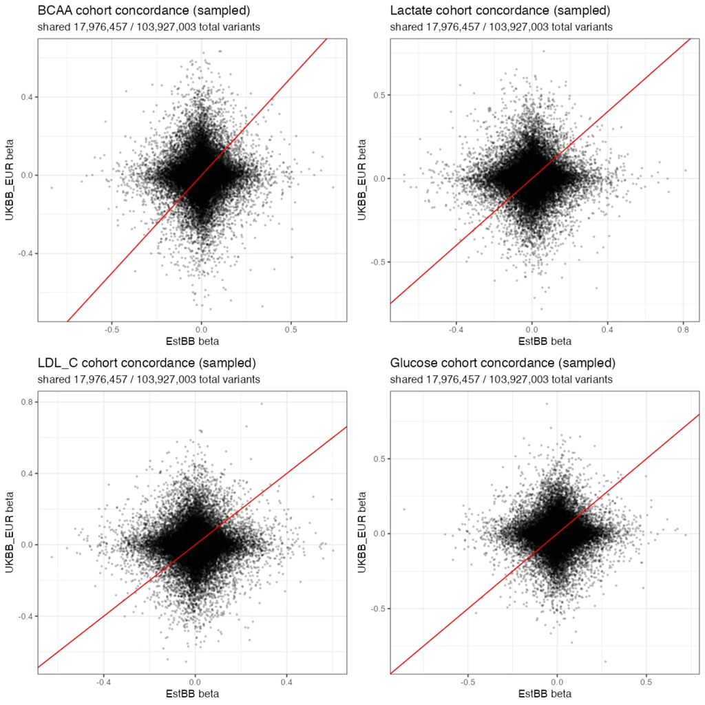

**Limitations.** This is a fixed-effect, inverse-variance-weighted meta-analysis, which assumes the two cohorts estimate the same underlying effect. The per-variant Cochran’s-*Q* is carried through so heterogeneous loci can be flagged, but a fixed-effect pooled estimate can still be misleading where the true effect genuinely differs between EstBB and UKBB. The no-flip join is deliberately conservative — strand-ambiguous or allele-mismatched variants are left uncombined rather than risk a silent mis-merge — so a small number of genuinely shared variants that a more aggressive allele-flipping step could have harmonised are instead reported from a single cohort. Finally, the validation here is a *reproduction* check against the authors’ own published meta over the identical cohorts: near-perfect agreement confirms the allele harmonisation and inverse-variance weighting are correct, but it does not independently replicate the association signal in a fresh sample the way a comparison against a separate study would. Nor does genome-wide reproduction validate every locus individually: a pooled hit with opposite-signed cohort effects and strong Cochran’s-*Q* heterogeneity should still be treated as potentially cohort-specific or artefactual rather than automatically as a shared biological association.

## 2.1 MCQ — Meta-analysis

**Two cohorts can be pooled for very different reasons: one cohort may simply dominate the result, or both may contribute evidence for the same underlying associations. Which description best matches the EstBB–UKBB_EUR analysis?**

- A. Most pooled LDL-C associations arose because large effects in EstBB compensated for effects in the opposite direction in UKBB_EUR.
- B. The cohorts generally supported effects in the same direction, and pooling strengthened a largely shared LDL-C association architecture.
- C. Pooling revealed that the two cohorts measured biologically different forms of LDL-C.
- D. The pooled results primarily reproduced variants observed only in UKBB_EUR, with minimal contribution from EstBB.

*Answer: **B.** The cross-cohort effect patterns are broadly concordant, and the independently reconstructed pooled effects match the published European meta-analysis. Together, those results support a largely shared LDL-C genetic architecture and justify combining the cohorts to increase association power, while heterogeneous individual loci remain subject to the Cochran’s-*Q* caveat discussed above.*

# 3 Heritability & genetic correlation (Step 2, LDSC)

With a genome-wide meta table in hand, this step characterises the *genetic architecture* of each trait using LD Score Regression (LDSC), which estimates SNP-based heritability and pairwise genetic correlation directly from summary statistics — no individual-level genotypes required, which is exactly the constraint this pipeline operates under. Two products matter here. First, per-(trait, dataset) SNP-heritability quantifies how much of each metabolite’s variance is tagged by common variants; computing it separately for EstBB, UKBB_EUR, and the meta gives a consistency check across cohorts. Second, following the paper’s design, two genetic-correlation analyses are run: **Analysis A** correlates the three datasets (EstBB, UKBB_EUR, meta_EUR) for each trait, which tests whether the two biobanks are measuring the same genetic signal and therefore whether meta-analysing them is justified; and **Analysis B** correlates the four traits within each dataset, which places the metabolites relative to one another.

The reasoning that shaped the step is that the estimates are only trustworthy if confounding is controlled, so the **LDSC intercept** is read as the key diagnostic and reported alongside every h² value. An intercept near 1 means the elevated test statistics reflect genuine polygenic signal rather than population stratification or cryptic relatedness; a markedly elevated intercept would instead flag confounding or sample overlap. This matters more than usual here because the pipeline later relies on an out-of-sample LD reference, so establishing up front that inflation is polygenic rather than artefactual is worth doing explicitly. On tooling, LDSC is run using the original `ldsc` implementation (Python 2.7) in its own conda environment, with the summary statistics pre-restricted to the ~1.2M HapMap3 rsIDs before munging — a memory-driven choice that keeps each job small enough to run comfortably on the 8 GiB machine. This step runs across **all four traits**.

| trait | dataset | h2 | h2_se | intercept |
| --- | --- | --- | --- | --- |
| BCAA | EstBB | 0.0634 | 0.0063 | 1.0268 |
| BCAA | UKBB_EUR | 0.0761 | 0.0065 | 1.0639 |
| BCAA | meta_EUR | 0.0652 | 0.0052 | 1.0808 |
| Lactate | EstBB | 0.0277 | 0.0036 | 1.073 |
| Lactate | UKBB_EUR | 0.0473 | 0.0033 | 1.0619 |
| Lactate | meta_EUR | 0.0389 | 0.0028 | 1.0785 |
| LDL_C | EstBB | 0.1617 | 0.0266 | 1.1416 |
| LDL_C | UKBB_EUR | 0.1105 | 0.0188 | 1.0878 |
| LDL_C | meta_EUR | 0.1175 | 0.0197 | 1.1555 |
| Glucose | EstBB | 0.0343 | 0.0044 | 1.0424 |

[output cut: 2 more lines]

| p1 | p2 | rg | se | z | p | h2_obs | h2_obs_se | h2_int | h2_int_se | gcov_int | gcov_int_se | trait | ds1 | ds2 |
| --- | --- | --- | --- | --- | --- | --- | --- | --- | --- | --- | --- | --- | --- | --- |
| BCAA.EstBB | BCAA.UKBB_EUR | 0.8332 | 0.0287 | 28.9917 | 8.3614e-185 | 0.077 | 0.0066 | 1.0596 | 0.0214 | 0.0218 | 0.0118 | BCAA | EstBB | UKBB_EUR |
| BCAA.EstBB | BCAA.meta_EUR | 0.918 | 0.0153 | 60.1022 | 0 | 0.066 | 0.0054 | 1.0763 | 0.0259 | 0.5892 | 0.0139 | BCAA | EstBB | meta_EUR |
| BCAA.UKBB_EUR | BCAA.meta_EUR | 0.971 | 0.0037 | 260.3238 | 0 | 0.0669 | 0.0055 | 1.0673 | 0.0211 | 0.8997 | 0.019 | BCAA | UKBB_EUR | meta_EUR |
| Lactate.EstBB | Lactate.UKBB_EUR | 0.8641 | 0.06 | 14.4122 | 4.3392e-47 | 0.0455 | 0.004 | 1.075 | 0.0227 | 0.0235 | 0.0134 | Lactate | EstBB | UKBB_EUR |
| Lactate.EstBB | Lactate.meta_EUR | 0.9402 | 0.0342 | 27.5195 | 1.027e-166 | 0.0371 | 0.0031 | 1.0967 | 0.0289 | 0.6169 | 0.0157 | Lactate | EstBB | meta_EUR |
| Lactate.UKBB_EUR | Lactate.meta_EUR | 0.966 | 0.0049 | 198.0364 | 0 | 0.0376 | 0.0029 | 1.0912 | 0.0249 | 0.9096 | 0.0214 | Lactate | UKBB_EUR | meta_EUR |
| LDL_C.EstBB | LDL_C.UKBB_EUR | 0.8531 | 0.0463 | 18.4302 | 7.5176e-76 | 0.0673 | 0.0307 | 1.3432 | 0.2628 | 0.2637 | 0.2134 | LDL_C | EstBB | UKBB_EUR |
| LDL_C.EstBB | LDL_C.meta_EUR | 0.9503 | 0.0155 | 61.3177 | 0 | 0.0777 | 0.0274 | 1.4734 | 0.3345 | 0.957 | 0.2552 | LDL_C | EstBB | meta_EUR |
| LDL_C.UKBB_EUR | LDL_C.meta_EUR | 0.9668 | 0.0071 | 136.6756 | 0 | 0.0813 | 0.0257 | 1.4328 | 0.3088 | 1.1701 | 0.2693 | LDL_C | UKBB_EUR | meta_EUR |
| Glucose.EstBB | Glucose.UKBB_EUR | 0.8971 | 0.0491 | 18.2895 | 1.0029e-74 | 0.0615 | 0.0086 | 1.0808 | 0.0238 | 0.0203 | 0.014 | Glucose | EstBB | UKBB_EUR |

[output cut: 2 more lines]

| p1 | p2 | rg | se | z | p | h2_obs | h2_obs_se | h2_int | h2_int_se | gcov_int | gcov_int_se | dataset | tr1 | tr2 |
| --- | --- | --- | --- | --- | --- | --- | --- | --- | --- | --- | --- | --- | --- | --- |
| BCAA.EstBB | Lactate.EstBB | 0.2635 | 0.0636 | 4.1455 | 3.391e-05 | 0.0264 | 0.0038 | 1.0774 | 0.0109 | 0.1634 | 0.006 | EstBB | BCAA | Lactate |
| BCAA.EstBB | LDL_C.EstBB | 0.1957 | 0.0688 | 2.8445 | 0.0044481 | 0.0942 | 0.0511 | 1.3358 | 0.2096 | 0.1109 | 0.0092 | EstBB | BCAA | LDL_C |
| BCAA.EstBB | Glucose.EstBB | 0.2236 | 0.0592 | 3.7755 | 0.00015968 | 0.0339 | 0.0054 | 1.0438 | 0.0099 | 0.0665 | 0.006 | EstBB | BCAA | Glucose |
| Lactate.EstBB | LDL_C.EstBB | 0.1195 | 0.071 | 1.6831 | 0.0924 | 0.0942 | 0.0511 | 1.3358 | 0.2096 | 0.0993 | 0.0082 | EstBB | Lactate | LDL_C |
| Lactate.EstBB | Glucose.EstBB | -0.2087 | 0.0829 | -2.5169 | 0.0118 | 0.0339 | 0.0054 | 1.0438 | 0.0099 | -0.507 | 0.0088 | EstBB | Lactate | Glucose |
| LDL_C.EstBB | Glucose.EstBB | 0.1958 | 0.0828 | 2.3637 | 0.0181 | 0.0339 | 0.0054 | 1.0438 | 0.0099 | 0.0278 | 0.0084 | EstBB | LDL_C | Glucose |
| BCAA.UKBB_EUR | Lactate.UKBB_EUR | 0.1893 | 0.0363 | 5.2105 | 1.8832e-07 | 0.046 | 0.0037 | 1.0699 | 0.0192 | 0.1141 | 0.008 | UKBB_EUR | BCAA | Lactate |
| BCAA.UKBB_EUR | LDL_C.UKBB_EUR | 0.0488 | 0.0514 | 0.9507 | 0.34177 | 0.0704 | 0.029 | 1.3172 | 0.2439 | 0.101 | 0.0205 | UKBB_EUR | BCAA | LDL_C |
| BCAA.UKBB_EUR | Glucose.UKBB_EUR | 0.2313 | 0.0297 | 7.7755 | 7.5142e-15 | 0.0624 | 0.0082 | 1.0744 | 0.0217 | 0.2494 | 0.0073 | UKBB_EUR | BCAA | Glucose |
| Lactate.UKBB_EUR | LDL_C.UKBB_EUR | 0.0536 | 0.0551 | 0.9732 | 0.33044 | 0.0704 | 0.029 | 1.3172 | 0.2439 | 0.0854 | 0.0166 | UKBB_EUR | Lactate | LDL_C |

[output cut: 8 more lines]

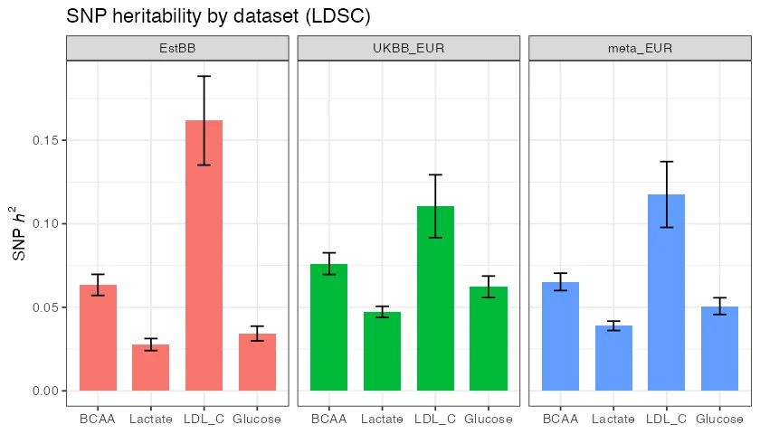

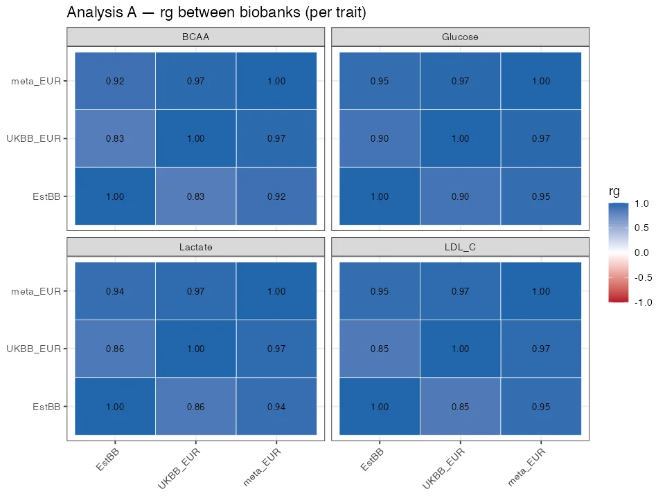

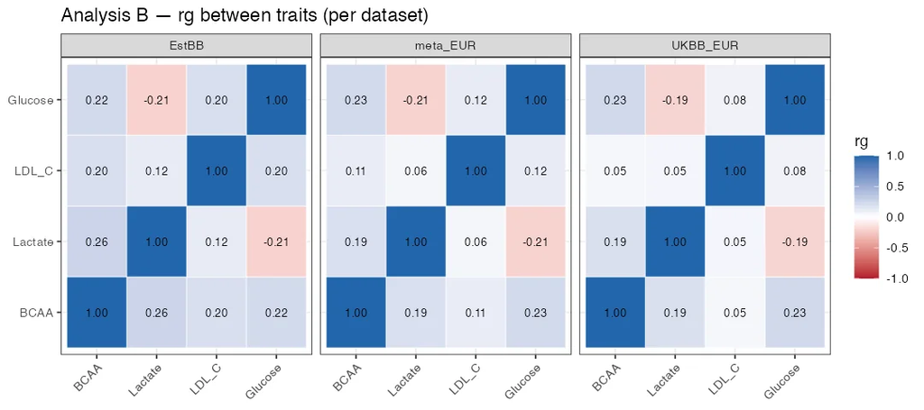

The tables and figures read out as follows. Every LDSC intercept sits near 1, so the test-statistic inflation is polygenic rather than confounded — the precondition for trusting the heritability estimates. The four traits carry modest, plausible SNP-heritabilities (LDL_C highest, lactate lowest), and Analysis A shows high between-biobank genetic correlation for each trait, which is the empirical justification for having meta-analysed EstBB and UKBB in Step 1. Analysis B places the traits relative to one another within each dataset. Together these confirm the meta table is well-behaved and that the two cohorts share genetic architecture strongly enough to pool.

**How this compares to the source manuscript.** Two comparisons hold up against the paper’s genome-wide figures. *Heritability:* across their 249 metabolites the authors report SNP-h² ranging from 2.8% (acetoacetate) to 19.5% (HDL size), median **10.2%** (their Supplementary Table 3 / Supplementary Fig. 1). Our four traits fall inside that envelope — LDL_C at **11.75%** sits almost exactly on their median, with BCAA (6.5%), Glucose (5.1%) and Lactate (3.9%) toward the lower-heritability end, consistent with amino-acid and glycolysis metabolites being less heritable than cholesterol traits in their data. *Cross-biobank genetic correlation:* the manuscript reports a median r_g of **0.91** (mean 0.89) between EstBB and UKBB for matched metabolic traits, taking that high shared genetic architecture as justification for meta-analysing the two biobanks. Our between-biobank r_g (EstBB vs UKBB_EUR) is 0.85 (LDL_C), 0.83 (BCAA), 0.90 (Glucose) and 0.86 (Lactate) — mean **0.86**, the same “largely shared effects” conclusion on the four traits we ran. The manuscript’s estimate is a genome-wide median over 249 traits and ours a four-trait mean, so the small gap is expected; the biological read-out is identical. The paper does not emphasise the LDSC intercept the way this report does — that diagnostic is highlighted here because out-of-sample issues (addressed at fine-mapping) make confounding-vs-polygenicity separation worth stating explicitly.

**Limitations.** LDSC heritability is a *common-variant, HapMap3-tagged* estimate: pre-restricting to the ~1.2M HapMap3 rsIDs is what makes the step tractable at 8 GiB, but it means rare-variant and poorly-tagged contributions to heritability are not captured, so these h² values are lower bounds on total SNP-heritability rather than complete accounts. The later observation of rare LDL-C leads with large per-allele effects is therefore not inconsistent with the moderate LDSC estimate: very rare alleles are poorly represented by HapMap3, and a large effect carried by few individuals need not explain a large fraction of population variance. LDSC also assumes a roughly polygenic architecture and a well-matched LD reference; for traits with a few very large-effect loci (LDL_C included) the regression can be sensitive to those loci, and the standard errors on a four-trait panel are wider than the paper’s genome-wide estimates over 249 traits. The genetic-correlation estimates inherit the same caveats and, for Analysis A, the EstBB and UKBB_EUR inputs are not fully independent of the meta they are correlated with, so those particular correlations are expected to run high by construction.

## 3.1 MCQ — Heritability and genetic correlation (LDSC)

**Imagine placing the four metabolites on a map with two axes: horizontal axis: contribution of common inherited variation; vertical axis: reproducibility of genetic effects between EstBB and UKBB. Which map would match the results?**

- A. Lactate would have the strongest common-variant contribution, while LDL-C would show the weakest cross-cohort reproducibility.
- B. All four metabolites would occupy nearly the same position on both axes.
- C. BCAA and glucose would show high heritability but little shared genetic architecture between cohorts.
- D. LDL-C would rank highest and lactate lowest for common-variant heritability, while all four traits would remain relatively high on cross-cohort reproducibility.

*Answer: **D.** The analysis places LDL-C at the highest and lactate at the lowest end of the four common-variant heritability estimates, while the consistently high EstBB–UKBB genetic correlations show that the traits’ inherited architectures are broadly shared across cohorts. Heritability and genetic correlation answer different questions: the traits can differ in the amount of variance tagged by common variants while remaining genetically reproducible between biobanks.*

# 4 Lead variants (Step 3)

Having established that the meta table is well-behaved, this step reduces the genome-wide-significant signal to a set of **independent lead variants** — one sentinel per locus — which become the scaffold for fine-mapping. Two design choices define the step, and the reasoning behind each is worth stating because both are deliberate departures from a naive threshold-and-clump.

The first is **frequency-dependent significance**. Common and low-frequency variants (MAF > 0.1%) are called at the standard genome-wide line, P < 5×10⁻⁸, but rare variants (MAF < 0.1%) are held to a stricter Bonferroni line, P < 0.05 / 8×10⁷ = 6.25×10⁻¹⁰. The reasoning is that the conventional 5×10⁻⁸ threshold is calibrated to roughly one million independent common-variant tests; the ~80M rare-variant tests in a genome-wide metabolite scan make that line anti-conservative for rare variants, so a tighter bar is needed to hold the family-wise error rate. Variants whose effect-allele frequency is unknown fall back to the standard line and are flagged `maf_class = "unknown"`, so a reader can weight them accordingly rather than having them silently mixed in.

The second is a **distance-based locus definition**. The most significant unclaimed variant is taken as a lead, a 2 Mb locus (±1 Mb) is claimed around it, every variant inside is removed, and the process iterates until no genome-wide-significant variant remains. This is a considered substitute rather than a shortcut: Step 3 operates on summary statistics only, with no genotype panel provided, so pairwise r² between variants is not computable and true LD clumping is not available. The distance rule is the standard, honest fallback in that situation. The paper’s additional r²≥0.05 locus-merge — which stops a single ultra-strong signal from “bleeding” past the 2 Mb window through long-range LD — and its r²≥0.8 cross-trait clustering both require a EUR genotype panel, so they are deferred to the LD-aware stage that Step 4 introduces.

| SNP | chr | pos | ea | oa | eaf | maf | maf_class | beta | se | z | pval | neg_log10p | n | direction | het_p | n_cohorts | locus_start | locus_end | n_sig_in_locus | source_file |
| --- | --- | --- | --- | --- | --- | --- | --- | --- | --- | --- | --- | --- | --- | --- | --- | --- | --- | --- | --- | --- |
| rs17035646 | 1 | 10736490 | A | G | 0.362260864970989 | 0.362260864970989 | common | -0.0128553853373458 | 0.00174445546054194 | -7.36928263754702 | 1.71548618292117e-13 | 12.7656127755415 | 599249 | -- | 0.278996096534152 | 2 | 9736490 | 11736490 | 15 | LDL_C.lead.tsv |
| rs10907282 | 1 | 16183644 | G | A | 0.640909577606304 | 0.359090422393696 | common | 0.0137905583022877 | 0.00174786816750278 | 7.88993046425841 | 3.02354957003783e-15 | 14.5194829068935 | 599249 | ++ | 0.400362762699634 | 2 | 15183644 | 17183644 | 94 | LDL_C.lead.tsv |
| rs10917383 | 1 | 23462501 | G | A | 0.875165450587318 | 0.124834549412682 | common | 0.0198033894847423 | 0.00252899944131541 | 7.83052347154412 | 4.858428218022591e-15 | 14.3135042094715 | 599249 | ++ | 0.548404831728484 | 2 | 22462501 | 24462501 | 66 | LDL_C.lead.tsv |
| rs11802413 | 1 | 25434429 | T | C | 0.555077642432445 | 0.444922357567555 | common | 0.0266000228705563 | 0.00168026244178149 | 15.8308739213106 | 1.90556033055431e-56 | 55.7199772967937 | 599249 | ++ | 0.264953216962982 | 2 | 24434429 | 26434429 | 253 | LDL_C.lead.tsv |
| rs114165349 | 1 | 26695422 | C | G | 0.0270055331620078 | 0.0270055331620078 | common | 0.0710595168787969 | 0.00513802819079599 | 13.830114246179 | 1.67753874732748e-43 | 42.7753274398289 | 599249 | ++ | 0.000459164298804166 | 2 | 25695422 | 27695422 | 242 | LDL_C.lead.tsv |
| rs60351648 | 1 | 38980726 | T | TTTTTC | 0.110087710270188 | 0.110087710270188 | common | 0.0155056263705386 | 0.00266419110933715 | 5.82001280471067 | 5.884311930113261e-09 | 8.23030431318172 | 599249 | ++ | 0.792743098697393 | 2 | 37980726 | 39980726 | 18 | LDL_C.lead.tsv |
| rs12407290 | 1 | 44809667 | G | C | 0.164355486100102 | 0.164355486100102 | common | 0.0146421121395105 | 0.00226556770382565 | 6.4628888003593 | 1.02722780718072e-10 | 9.98833323271205 | 599249 | ++ | 0.910717546361725 | 2 | 43809667 | 45809667 | 120 | LDL_C.lead.tsv |
| rs1264731440 | 1 | 48850184 | C | T | 0.000161705 | 0.000161705 | rare | -0.517003 | 0.0827818 | -6.24537035918523 | 4.22797087107751e-10 | 9.37386801345872 | 413897 | ?- |  | 1 | 47850184 | 49850184 | 1 | LDL_C.lead.tsv |
| rs536731403 | 1 | 50914981 | G | C | 0.000159863 | 0.000159863 | rare | -0.556532 | 0.0842036 | -6.60936111995212 | 3.85982126221126e-11 | 10.4134328058548 | 413897 | ?- |  | 1 | 49914981 | 51914981 | 3 | LDL_C.lead.tsv |
| rs371216881 | 1 | 52296038 | A | G | 0.000157721 | 0.000157721 | rare | -0.571357 | 0.0848227 | -6.73589734823343 | 1.62921282251013e-11 | 10.7880221805137 | 413897 | ?- |  | 1 | 51296038 | 53296038 | 13 | LDL_C.lead.tsv |

[output cut: 311 more lines]

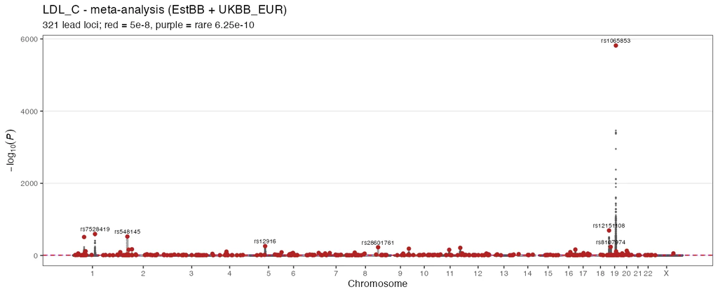

The headline result of this step is the **concordance with the published loci**. Benchmarked against the authors’ `meta_EUR` LDL_C lead variants, this step recovers **96.3%** (310/322) of their loci at the exact lead position — 321 leads called here against 322 published. That level of agreement from an independent summary-statistic reimplementation supports the lead-calling procedure. Importantly, Step 3 uses association statistics and physical distance only, so the residual discrepancies cannot be attributed to the out-of-sample 1000G-EUR LD reference used later in Step 4. They more plausibly reflect differences in variant availability or frequency annotation and the use of fixed distance windows rather than the authors’ LD-based locus merging. The Manhattan plot shows the genome-wide signal with the called leads marked.

**Limitations.** The distance-only locus definition is the main scientific limitation of this step: a single very strong signal (−log₁₀P ≫ 100) can carry association past the fixed ±1 Mb window through LD, and a distance rule has no way to know two adjacent windows tag the same causal variant, so one true signal can be split into several apparent “independent” loci. This is precisely what the paper’s r²≥0.05 merge exists to prevent, and it is only avoidable with a matched genotype panel — which Step 3 does not have. The frequency-dependent threshold, while defensible, uses a fixed ~80M denominator for the rare-variant Bonferroni line rather than the true number of independent rare tests, so it is approximate. And because effect-allele frequency is missing for some variants, the `unknown` class is called at the looser line and may include a small number of rare variants that a complete frequency annotation would have held to the stricter bar. Accordingly, an unknown-frequency lead that later proves rare and passes only the standard 5×10⁻⁸ threshold should be treated as provisional, not as a secure rare-variant discovery. Likewise, physical separation alone is not evidence of independence: two leads outside the ±1 Mb exclusion window may still represent one biological signal if long-range LD connects them.

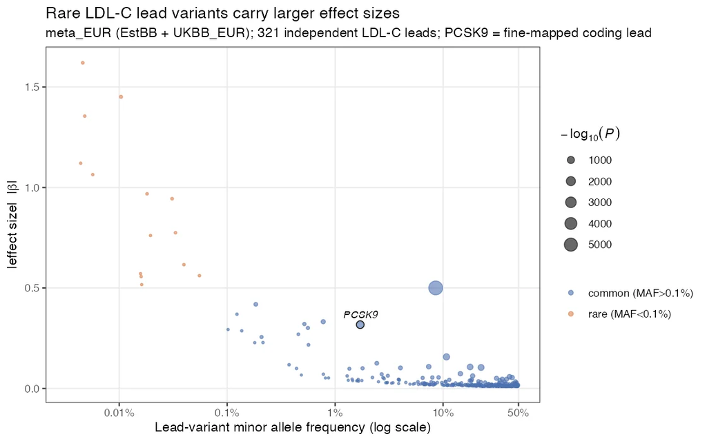

## 4.1 MCQ — Lead variants

**A follow-up study must choose one design based on the observed LDL-C lead-variant architecture. Which design is most consistent with the analysis?**

- A. Focus exclusively on Mendelian families because LDL-C appears to be governed mainly by rare, highly penetrant mutations.
- B. Increase common-variant GWAS sample size but exclude rare variants because their observed effects were negligible.
- C. Combine larger common-variant association studies with targeted sequencing or functional follow-up of rarer, larger-effect variants.
- D. Treat allele frequency as irrelevant because common and rare lead variants showed comparable effect-size distributions.

*Answer: **C.** The lead-variant distribution contains many common small-effect associations and a smaller group of rare, larger-effect associations. This supports a mixed genetic architecture rather than a purely common-variant or rare-variant model. Larger per-allele effects do not imply that rare variants explain most population variance, because their low frequencies sharply limit how many individuals carry them.*

# 5 Fine-mapping + coding annotation (Step 4)

The lead variants mark *where* the associations are; this step asks *which variant* at each locus is most plausibly causal, and *what gene* it acts through. Each locus is fine-mapped with **SuSiE** (the summary-statistics form, SuSiE-RSS), which decomposes the regional signal into one or more credible sets, each a small set of variants with a posterior inclusion probability (PIP) that one of them is causal. The credible-set variants are then annotated for coding consequence (missense via Ensembl VEP), so a fine-mapped signal can be connected to a candidate effector gene. The MHC region is excluded because its extreme, long-range LD breaks the fine-mapping assumptions.

The scope here is a deliberate, reasoned narrowing. Rather than fine-map genome-wide, this step targets the **11 canonical LDL effector loci for LDL_C only**. The thinking is that LDL_C is the positive control and these 11 loci have known biology, so restricting to them lets the out-of-sample LD behaviour be inspected locus by locus — where a credible set is well-behaved and where it is not — instead of being averaged into a genome-wide count. Two SuSiE settings follow directly from the out-of-sample-LD concern: `estimate_residual_variance` is fixed to `FALSE`, and an `estimate_s_rss` LD-mismatch diagnostic is computed per locus, both of which are the documented remedies for running SuSiE-RSS against a reference panel that is not the GWAS sample.

| trait | gene | chr | ID | POS | ea | oa | pip | z | r2_lead | cs | coverage | pass_filter | most_severe | consequence | impact | is_missense | gene_symbol | is_expected_gene | aa_change | codons | sift_pred | sift_score | polyphen_pred | polyphen_score | biotype | allele_match | is_known_causal | source_file |
| --- | --- | --- | --- | --- | --- | --- | --- | --- | --- | --- | --- | --- | --- | --- | --- | --- | --- | --- | --- | --- | --- | --- | --- | --- | --- | --- | --- | --- |
| LDL_C | PCSK9 | 1 | rs9803730 | 54598773 | A | G | 1 | -1.75980014480915 | 0.042306319225 | 10 | 0.95 | False | non_coding_transcript_exon_variant | intron_variant | MODIFIER | False | ACOT11 | False |  |  |  |  |  |  | protein_coding | ea | False | LDL_C.annot.tsv |
| LDL_C | PCSK9 | 1 | rs541575683 | 54933454 | A | G | 1 | 1.80799491765626 | 0.091778096601 | 3 | 0.95 | False | intron_variant | intron_variant | MODIFIER | False | DHCR24-DT | False |  |  |  |  |  |  | lncRNA | ea | False | LDL_C.annot.tsv |
| LDL_C | PCSK9 | 1 | rs191898211 | 54981236 | A | G | 1 | -8.36455256355766 | 0.00023946324516 | 9 | 0.95 | True | intron_variant | intron_variant | MODIFIER | False | TMEM61 | False |  |  |  |  |  |  | protein_coding | ea | False | LDL_C.annot.tsv |
| LDL_C | PCSK9 | 1 | rs11591147 | 55039974 | T | G | 1 | -48.4568685090653 | 1 | 1 | 0.95 | True | missense_variant | missense_variant | MODERATE | True | PCSK9 | True | R46L | cGt/cTt | tolerated | 0.32 | benign | 0 | protein_coding | ea | True | LDL_C.annot.tsv |
| LDL_C | PCSK9 | 1 | rs563641 | 55058714 | C | T | 1 | 8.49298753194857 | 0.019109468169 | 7 | 0.95 | True | intron_variant | intron_variant | MODIFIER | False | PCSK9 | True |  |  |  |  |  |  | protein_coding | ea | False | LDL_C.annot.tsv |
| LDL_C | PCSK9 | 1 | rs12750160 | 55208327 | T | C | 1 | -20.7699028851317 | 0.142384720921 | 5 | 0.95 | True | intron_variant | intron_variant | MODIFIER | False | USP24 | False |  |  |  |  |  |  | protein_coding | ea | False | LDL_C.annot.tsv |
| LDL_C | PCSK9 | 1 | rs184444574 | 55449104 | G | A | 0.999999995120986 | 1.93906091409544 | 0.058775214096 | 6 | 0.95 | False | intron_variant | intron_variant | MODIFIER | False | LINC01755 | False |  |  |  |  |  |  | lncRNA | ea | False | LDL_C.annot.tsv |
| LDL_C | PCSK9 | 1 | rs11206517 | 55060755 | G | T | 0.99379995108963 | 15.9794623844898 | 0.00038999140324 | 4 | 0.95 | True | intron_variant | intron_variant | MODIFIER | False | PCSK9 | True |  |  |  |  |  |  | protein_coding | ea | False | LDL_C.annot.tsv |
| LDL_C | PCSK9 | 1 | rs146044567 | 54659319 | A | G | 0.988686248130772 | -0.0639445197223559 | 0.021247143696 | 8 | 0.95 | False | intron_variant | intron_variant | MODIFIER | False | MROH7 | False |  |  |  |  |  |  | protein_coding | ea | False | LDL_C.annot.tsv |
| LDL_C | PCSK9 | 1 | rs693668 | 55055436 | A | G | 0.629957337405671 | 24.9556886486786 | 3.0683477889e-06 | 2 | 0.95 | True | intron_variant | intron_variant | MODIFIER | False | PCSK9 | True |  |  |  |  |  |  | protein_coding | ea | False | LDL_C.annot.tsv |

[output cut: 122 more lines]

Only the credible-set variants annotated as **missense** are shown below — these are the coding candidates that fine-mapping nominates as potentially causal. Recovering textbook LDL coding variants (PCSK9 R46L, APOE C130R) at PIP = 1 provides a strong positive-control check at those loci, although it does not establish calibration across every locus under the out-of-sample LD reference.

| gene_symbol | ID | aa_change | pip | cs | sift_pred | polyphen_pred | is_known_causal |
| --- | --- | --- | --- | --- | --- | --- | --- |
| PCSK9 | rs11591147 | R46L | 1 | 1 | tolerated | benign | True |
| ABCG5 | rs141828689 | R198Q | 1 | 5 | deleterious | probably_damaging | False |
| APOE | rs429358 | C130R | 1 | 7 | tolerated |  | False |
| APOB | rs1367117 | T98I | 0.145038947337568 | 3 | deleterious | benign | False |
| ABCG8 | rs4148217 | T400K | 0.0407494245470542 | 10 | deleterious | benign | False |

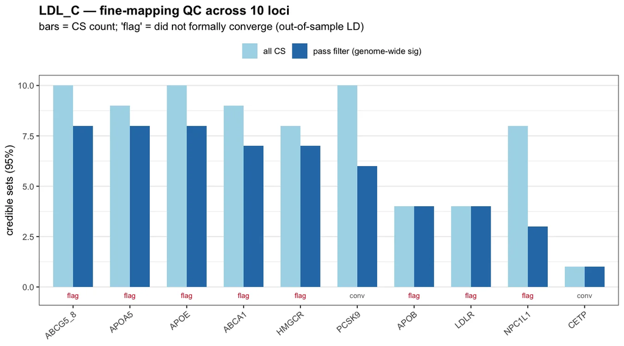

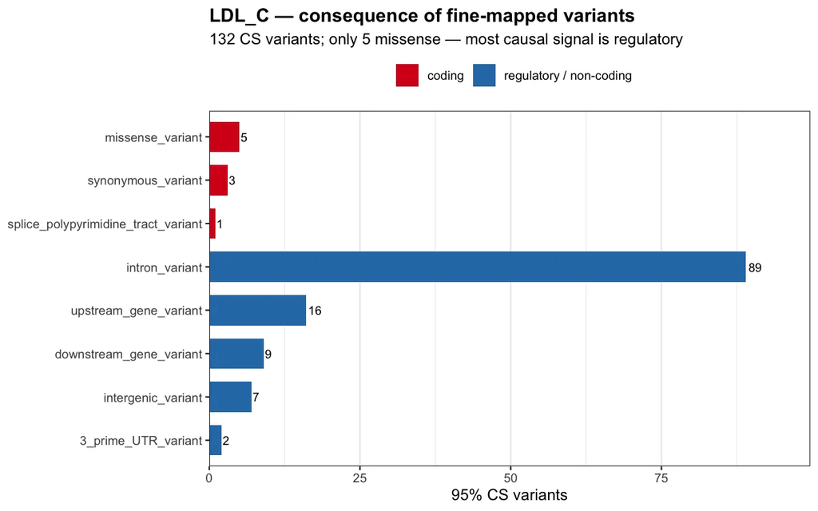

Three representative loci are featured here, of the 11 fine-mapped. PCSK9 shows the R46L drug-target coding variant recovered at high PIP; ABCG5/ABCG8 shows two missense variants across a two-gene locus; and APOE shows a locus resolved into multiple credible sets (allelic heterogeneity). The remaining loci are summarised in the two figures above and available in the repository.

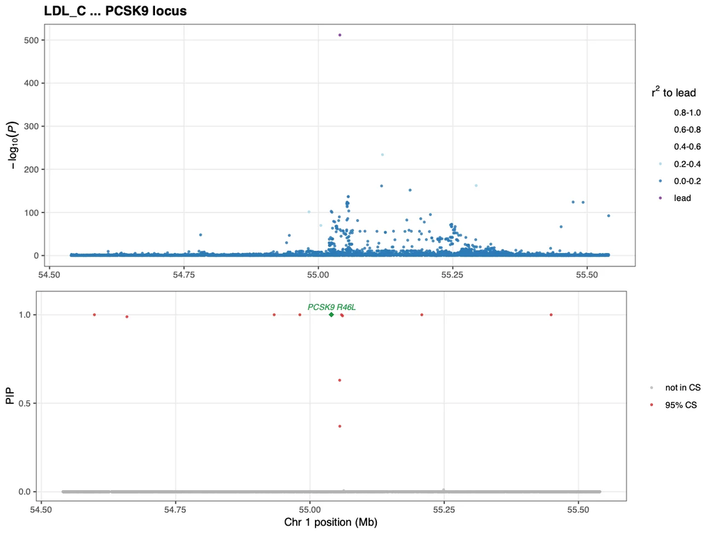

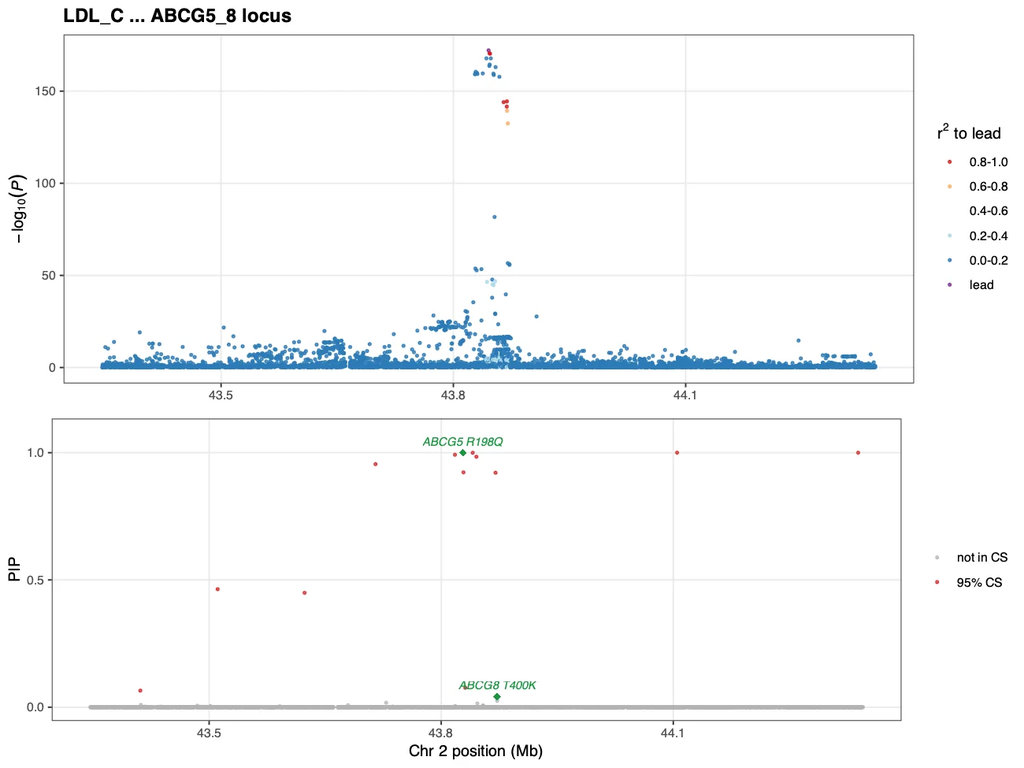

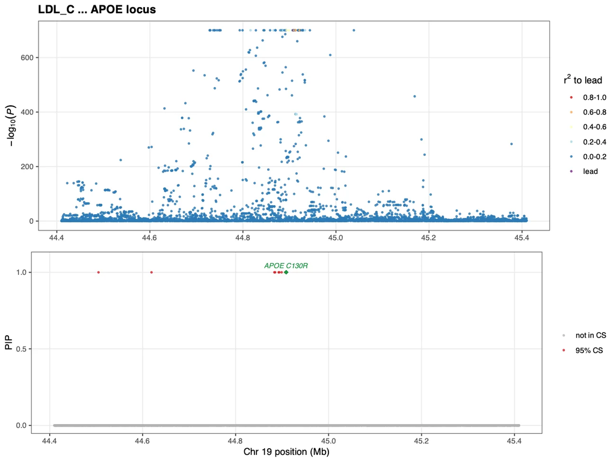

**Limitations.** The out-of-sample 1000G EUR LD reference is the single most important caveat of the whole analysis, and it bites hardest here: SuSiE-RSS assumes the LD matrix matches the GWAS sample, and a mismatched reference can miscalibrate PIPs and produce spurious or oversized credible sets. The fingerprint of that mismatch is visible in the convergence QC — most loci hit the IBSS iteration cap — which is why the LD-mismatch diagnostic is reported per locus and the residual variance is fixed rather than estimated. Recovery of strong positive controls such as PCSK9 R46L and APOE C130R shows that some well-tagged local signals remain identifiable, but it does not establish that PIPs and credible-set membership are calibrated at every locus; loci with convergence or mismatch warnings must still be interpreted cautiously. Two further limits bound what this step can claim. The scope is 11 LDL effector loci for one trait, so it is a hypothesis-driven probe of the method’s calibration, not a genome-wide fine-mapping result. And coding annotation explains only a minority of the signal: of the credible-set variants only a handful are missense, while most are regulatory or intronic and cannot be assigned an effector gene from sequence consequence alone — resolving those requires the molecular-QTL colocalization of the next step. Splice-effect prediction (SpliceAI / AlphaGenome) is not part of this replication, so splice-altering credible-set variants are not identified here.

## 5.1 MCQ — Fine-mapping

**After fine-mapping the canonical LDL-C loci and annotating the resulting credible-set variants, which biological model was best supported?**

- A. LDL-C associations involve a mixture of protein-altering and noncoding mechanisms: several loci prioritized established missense variants, while most prioritized variants were regulatory or intronic.
- B. Nearly every LDL-C association was resolved to a missense variant, indicating that altered protein sequence is the dominant mechanism across loci.
- C. No coding candidates were identified, indicating that LDL-C genetics acts entirely through gene regulation.
- D. Fine-mapping supported one identical molecular mechanism across all LDL-C loci.

*Answer: **A.** Fine-mapping recovered established protein-altering candidates at loci including PCSK9, APOE, APOB and ABCG5/ABCG8, but most credible-set variants were noncoding. The analysis therefore supports mechanistic heterogeneity: some LDL-C associations plausibly act through altered protein sequence, whereas many others require regulatory evidence to identify the effector gene and molecular mechanism.*

# 6 Colocalization with molecular QTLs (Step 5)

Fine-mapping (Step 4) narrows each locus to a short list of candidate causal variants, but a credible set does not by itself name the gene through which a variant acts. Colocalization answers that question: it asks whether the LDL-C association and a molecular-QTL association at the same locus are driven by *one shared causal variant* — evidence that the trait signal acts through that molecular phenotype (a gene’s expression, splicing, or protein level) — or by two *distinct* variants that happen to sit nearby. This is the step that converts a statistical locus into a candidate effector gene with a mechanism attached.

**Analysis and scope.** For each of the LDL-C effector loci I tested the GWAS signal against molecular QTLs using `coloc.abf` (the single-causal-variant approximate Bayes factor model) with the same priors the reference paper adopted (`p1 = p2 = 1e-4`, `p12 = 5e-6`). Two design choices carry the reasoning of this step. First, **tissue is chosen from the data, not assumed.** Liver is the biologically obvious tissue for LDL, but the eQTL Catalogue has only one liver dataset (GTEx, n=208) and it fine-maps none of these genes — so, exactly as the reference paper (a genome-wide `gpu-coloc` scan over the whole Catalogue) and Open Targets do, I scan every gene-level dataset across all seven quantification methods (`ge`, `exon`, `tx`, `txrev`, `leafcutter`, `microarray`, and `aptamer` protein levels) and colocalize each gene against the best-powered dataset that actually fine-maps it. Second, **the molecular layer is broad on purpose.** Restricting to bulk gene-expression QTLs would miss the mechanism at loci that act through splicing (captured by `exon`/`leafcutter`) or through circulating protein level (captured by the `aptamer` pQTLs) — so all quant methods are in scope and the winning method is reported per gene. The scope of this replication is deliberately narrower than the paper in one respect: the published study embeds colocalization in a disease → trait → molecular-QTL triplet graph, whereas this pipeline has no disease (e.g. coronary artery disease) layer, so I recover the trait ↔︎ molecular-QTL half of that graph at the canonical LDL effector loci.

| Gene | QTL type | Tissue | PP.H4 | PP.H3 | shared SNPs | Outcome |
| --- | --- | --- | --- | --- | --- | --- |
| HMGCR | exon | skin | 1 | 0 | 1667 | colocalizes (shared causal variant) |
| APOA5 | aptamer | plasma | 0.993 | 0.007 | 2352 | colocalizes (shared causal variant) |
| CETP | ge | lung | 0.988 | 0.012 | 1977 | colocalizes (shared causal variant) |
| ABCG5 | ge | spleen | 0.972 | 0.028 | 1770 | colocalizes (shared causal variant) |
| PCSK9 | ge | tibial nerve | 0.939 | 0.061 | 2376 | colocalizes (shared causal variant) |
| APOE | aptamer | plasma | 0.277 | 0.723 | 2086 | distinct causal variants |
| LPL | leafcutter | brain (caudate) | 0.145 | 0.851 | 1994 | distinct causal variants |
| LDLR | ge | CD4+ T cell | 0.033 | 0.115 | 1351 | GWAS-only (QTL null in tissue) |
| NPC1L1 | exon | adipose | 0.023 | 0.266 | 1344 | GWAS-only (QTL null in tissue) |
| ABCG8 | exon | adipose | 0.02 | 0.212 | 2068 | GWAS-only (QTL null in tissue) |

[output cut: 2 more lines]

**Results.** Of the 12 effector genes carried forward (each tested against its best-powered fine-mapping dataset, out of 45 gene × quantification-method candidates in total), **five colocalize at PP.H4 ≥ 0.80**: HMGCR (PP.H4 = 1.00, skin exon-QTL), APOA5 (0.99, plasma protein level), CETP (0.99, lung expression), ABCG5 (0.97, spleen expression) and PCSK9 (0.94, tibial-nerve expression). The two textbook druggable LDL targets in the set — HMGCR (the statin target) and PCSK9 (the target of evolocumab/alirocumab) — both colocalize, which is the positive control that tells us the pipeline is finding real shared signals rather than noise. The remaining genes split into two informative classes. Four show a high probability of **distinct causal variants** (PP.H3): ABCA1 (0.99), APOB (0.96), LPL (0.85) and APOE (0.72) — the trait and the molecular QTL both associate at the locus, but through different causal variants, so the tested molecular phenotype in that tissue is not the mechanism. APOB is the instructive case: it carries strong coding-haplotype biology, and the LDL signal there is not explained by the skin exon-QTL, consistent with a direct protein-coding rather than an expression-regulatory mechanism. The last three — ABCG8, LDLR and NPC1L1 — are **GWAS-only** (high PP.H1): the molecular QTL is simply not associated in the tissue tested, most likely a power or tissue-context limitation rather than evidence against the gene. Taken together, the loci do not support one uniform molecular mechanism. Some are consistent with a shared regulatory, splicing or protein-level signal, whereas others — APOB most clearly — are better explained by a coding mechanism than by the tested molecular QTL. The tissue label of a successful colocalization should also not be read automatically as the physiological tissue of action: regulatory QTLs can be shared across tissues, and the only available liver dataset was too small to fine-map any of these genes. The non-liver findings therefore nominate shared variant–molecular-phenotype relationships without excluding liver mediation.

The colocalization outcome for every effector gene, decomposing the posterior into PP.H4 (one shared causal variant, red) versus PP.H3 (two distinct causal variants, grey). The dashed line marks the PP.H4 = 0.80 colocalization threshold. Genes separate cleanly into the five that colocalize on a shared variant and the loci that resolve to distinct signals.

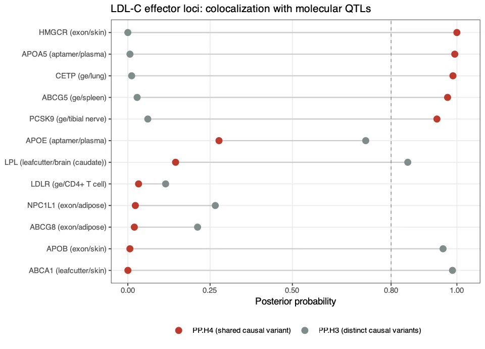

Regional colocalization plots for the five colocalizing genes, each in the reference paper’s Supplementary-Figure-7 style: the LDL-C GWAS association (top) stacked over the molecular-QTL association (bottom) on a shared genomic axis, with the lead variant of each panel marked and PP.H4 annotated. A shared causal variant shows up as the two peaks coinciding. This is a two-panel analogue of the paper’s three-panel figure — we have no disease-GWAS layer to add on top.

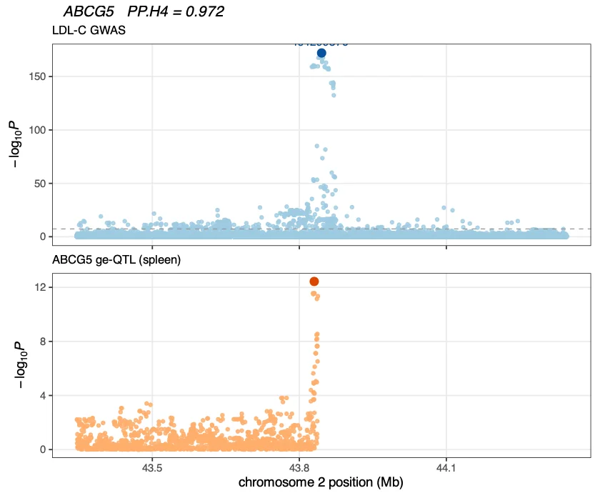

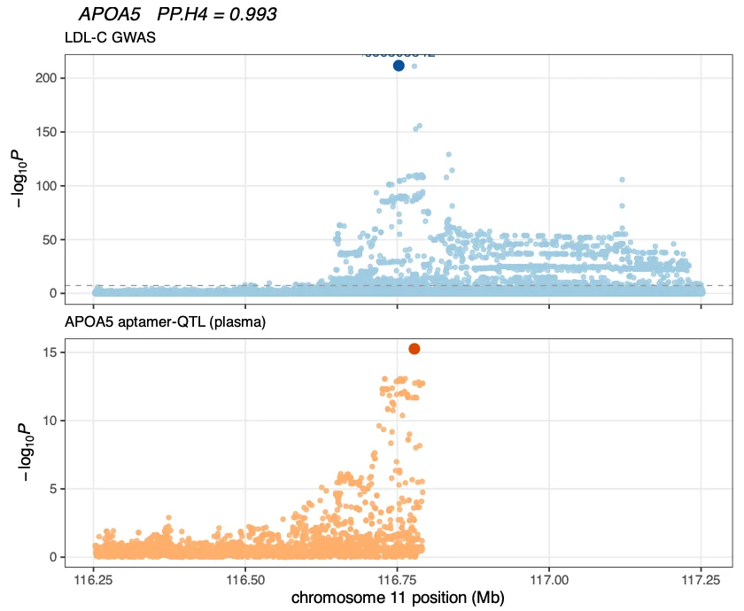

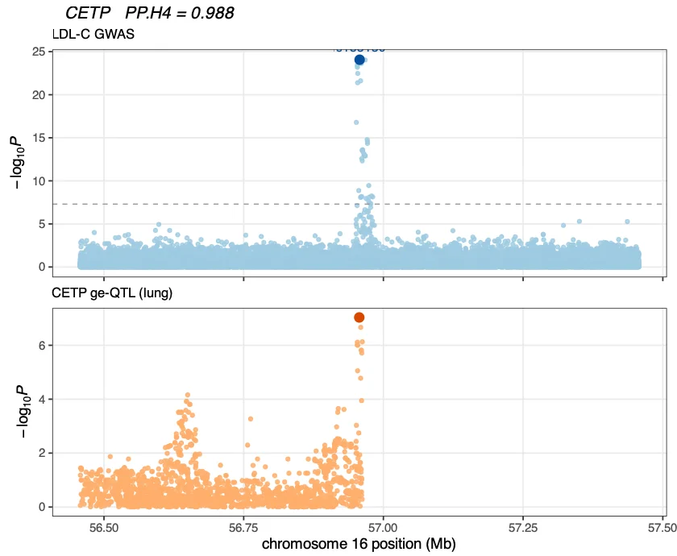

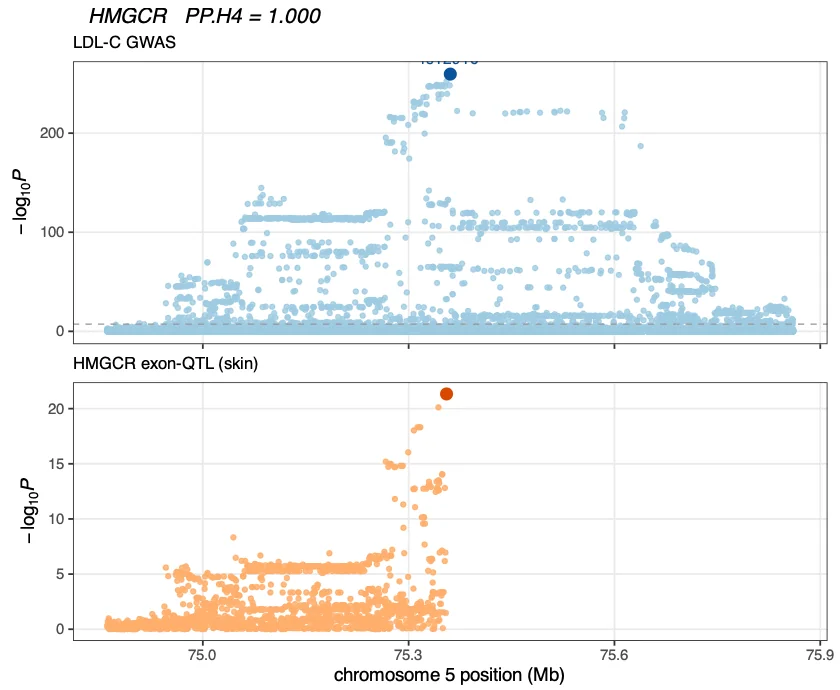

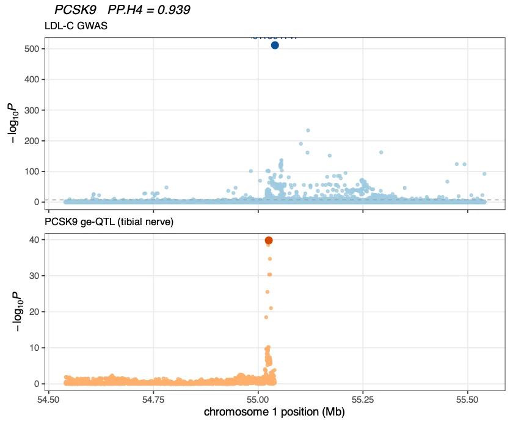

**How this compares to the source manuscript.** The correspondence is at the level of method and priors, not counts. The paper runs `gpu-coloc` genome-wide over SuSiE-fine-mapped Bayes factors (`coloc.bf_bf`) with priors `p1 = p2 = 1e-4`, `p12 = 5e-6`; this replication uses the single-signal `coloc.abf` on marginal statistics with the identical priors, which is the deliberately simpler, CPU-tractable case of the same model. Because the published analysis is genome-wide and disease-anchored while this one is a targeted trait-versus-molecular-QTL sweep over a handful of LDL effector loci, the honest comparison is *shared-signal recovery at known loci*, and it holds: the flagship recreation is HMGCR, where the LDL-C GWAS lead **rs12916** and the skin exon-QTL peak both resolve to the same narrow region — the QTL peak sits on **5-75355259**, the very variant the paper’s Supplementary Figure 7 highlights as the fine-mapped causal SNP (PIP ≈ 0.64) — reproducing that figure’s visual signature of a PP.H4 ≈ 1.0 colocalization from an independent implementation.

**Limitations.** Colocalization is only as informative as the molecular data behind it, and three limits bound what this step can claim. First, **it is tissue- and context-specific**: a null result (the three GWAS-only genes) means the QTL was not associated in the *tissue tested*, not that the gene is not causal — the true effector tissue may simply be absent or underpowered in the Catalogue, which is precisely why liver could not be used for any of these genes. Second, **`coloc.abf` assumes a single causal variant per locus**; at loci with allelic heterogeneity (which the Step-4 fine-mapping already showed exists here) that assumption can understate a true colocalization or misassign the shared variant, and the paper’s SuSiE-based `coloc.bf_bf` is the more faithful model for exactly that reason. Third, **the GWAS side inherits the out-of-sample-LD caveat** from the whole analysis — the marginal statistics are unaffected, but any locus where fine-mapping was already shaky is one to read with corresponding caution. Finally, a shared causal variant is strong evidence of a mechanism but not proof of causality for the trait; that step is Mendelian randomization (Steps 6–7).

## 6.1 MCQ — Colocalization

**Which mechanistic map most accurately summarizes what the colocalization analysis added to the fine-mapping results?**

- A. Every LDL-C locus was assigned to a liver-expression mechanism, eliminating the need to consider coding effects or other tissues.
- B. Some loci, including HMGCR and PCSK9, supported a shared LDL-C–molecular-QTL signal; APOB favored a distinct coding mechanism; and several other loci remained unresolved because the available QTL context was uninformative.
- C. Any molecular QTL located near an LDL-C association was considered the causal mediator, regardless of whether the association peaks aligned.
- D. Failure to detect a shared molecular-QTL signal excluded LDLR, NPC1L1 and ABCG8 from LDL-C biology.

*Answer: **B.** The results separated the loci into shared-signal, distinct-signal and GWAS-only classes rather than assigning one universal regulatory mechanism. The analysis supports locus-specific mechanisms rather than one universal route. HMGCR and PCSK9 provide evidence that the LDL-C and molecular-QTL associations can share a causal signal, while APOB favors distinct GWAS and exon-QTL signals and also carries an independently fine-mapped missense candidate. Thus, proximity to a molecular QTL is not sufficient to assign mediation, and lack of colocalization in an available tissue does not exclude a known effector gene.*

# 7 Genome-wide Mendelian randomization (Step 6)

Colocalization (Step 5) tests whether an LDL-C association and a molecular-QTL association share a causal variant, but it does not establish whether LDL-C itself influences coronary artery disease. Mendelian randomization (MR) addresses this question by using LDL-C-associated variants as instruments and testing whether their effects on LDL-C are systematically related to their effects on CAD. Because genetic variants are assigned before disease onset, MR is less susceptible than observational analysis to reverse causation and conventional environmental confounding. Its causal interpretation nevertheless depends on the validity of the genetic instruments, particularly the assumption that they do not influence CAD through pathways independent of LDL-C.

**Analysis and scope.** MR is run at two levels, with the outcome fixed to the European-ancestry CAD GWAS (`GCST90132314`; 181,522 cases). **Genome-wide MR (Step 6)** tests the causal effect of LDL-C as a circulating trait. Genome-wide-significant lead variants with MAF >1% and $P<5\times10^{-8}$ are greedily LD-pruned at $r^2<0.01$ using the 1000G-EUR panel, harmonized to the CAD outcome, and combined using multiplicative random-effects inverse-variance-weighted MR. **cis-MR (Step 7)** evaluates LDL-C-associated variation within ±200 kb of four nominated LDL-related genes: **PCSK9**, **HMGCR**, **NPC1L1**, and **LDLR**. The cis analysis uses multiplicative random-effects IVW with delta-method weights and MR-Egger as a directional-pleiotropy sensitivity analysis. Genome-wide MR therefore asks whether LDL-C as a trait influences CAD, whereas cis-MR asks whether evidence from a particular genomic region is consistent with an LDL-C-mediated effect on CAD.

| Exposure | Outcome | Method | #instruments | OR per SD | 95% CI | P |
| --- | --- | --- | --- | --- | --- | --- |
| LDL_C | CAD | IVW (mult. random-effects) | 219 | 1.663 | 1.529 – 1.808 | 1.49e-32 |

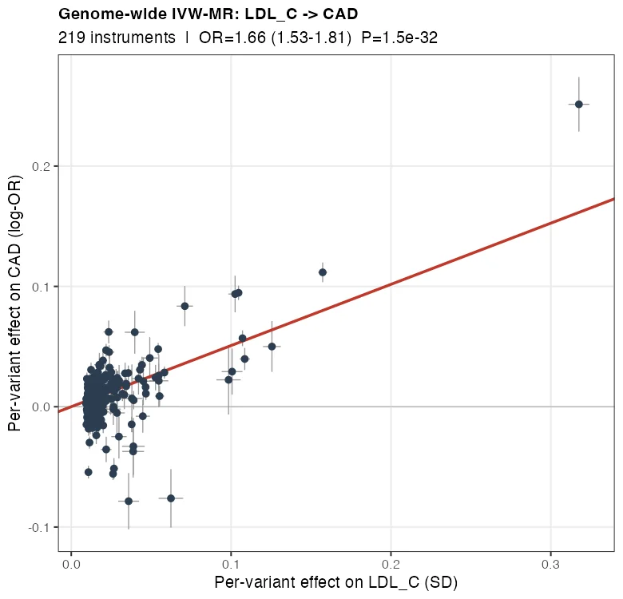

[figure not shown]

*Genome-wide MR of LDL-C on CAD. Each point is a pruned instrument: per-allele effect on LDL-C (x) against effect on CAD (y); the fitted slope is the IVW causal estimate.*

The direction and magnitude are consistent with the established causal relationship between higher LDL-C and coronary disease, making this an important positive-control result for the pipeline. The analysis supports a **trait-level** causal interpretation under the MR assumptions. It does not identify which LDL-regulating gene mediates the effect, establish that every LDL-lowering mechanism has the same effect on CAD, or independently exclude horizontal pleiotropy. Because the scoped replication uses the manuscript’s primary genome-wide IVW estimator without additional sensitivity estimators, the result should be interpreted as the prespecified IVW estimate rather than as a comprehensive pleiotropy-robust analysis.

## 7.1 MCQ — Genome-wide Mendelian randomization

**A reviewer asks which biological claim is directly supported by the genome-wide MR analysis, without importing conclusions from colocalization or cis-MR. Which answer is defensible?**

- A. Every intervention that lowers LDL-C will have the same clinical effect on CAD.
- B. The analysis excludes all forms of horizontal or correlated pleiotropy among the instruments.
- C. Genetic predisposition to higher circulating LDL-C is associated with increased CAD risk at the trait level, consistent with a causal effect.
- D. The genome-wide instruments identify which individual LDL-regulating gene should be pharmacologically targeted.

*Answer: **C.** The genome-wide analysis used multiplicative random-effects IVW as its prespecified estimator and produced a positive LDL-C-to-CAD estimate. It supports the trait-level causal conclusion, but it was not designed to identify a specific target or comprehensively exclude pleiotropy.*

# 8 Cis Mendelian randomization: drug-target validation (Step 7)

cis-MR complements the genome-wide analysis by restricting instruments to the genomic region around a nominated gene. Candidate instruments are selected from ±200 kb around the full gene body, must have MAF >1% and $P<5\times10^{-8}$, and are greedily pruned at $r^2<0.01$ using 1000G-EUR LD. The four regions examined are **PCSK9**, **HMGCR**, **NPC1L1**, and **LDLR**. PCSK9, HMGCR, and NPC1L1 correspond to established pharmacological targets, whereas LDLR is included because of its central role in LDL clearance.

A positive cis-MR estimate means that LDL-C-associated variation within the nominated region also predicts CAD risk. This is evidence consistent with the biological mechanism represented by that region, but it does not prove that every instrument acts exclusively through the named gene. Nearby variants may regulate multiple genes, residual LD may remain after pruning, and horizontal pleiotropy can still occur within a cis region.

| Gene | Chr | Drug | #instr | IVW OR per SD | 95% CI | IVW P | Egger dir. pleiotropy |
| --- | --- | --- | --- | --- | --- | --- | --- |
| NPC1L1 | 7 | ezetimibe | 5 | 2.4 | 1.91 – 3.01 | 5.95e-14 | nominal (P=0.033) |
| PCSK9 | 1 | evolocumab / alirocumab | 11 | 2.25 | 2.02 – 2.51 | 6.54e-50 | no (P≥0.05) |
| LDLR | 19 | (LDL receptor) | 33 | 2.02 | 1.88 – 2.18 | 9.579999999999999e-77 | no (P≥0.05) |
| HMGCR | 5 | statins | 10 | 1.52 | 1.36 – 1.70 | 1.25e-13 | nominal (P=0.046) |

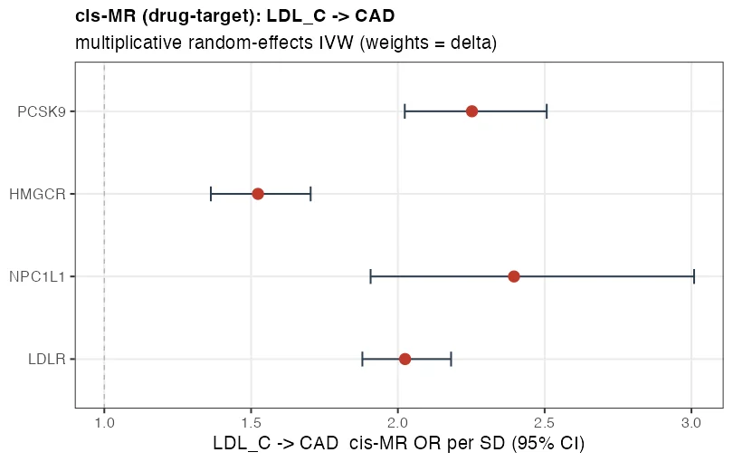

[figure not shown]

*Per-gene cis-MR estimates for the LDL drug-target genes, each instrumented only from its own ±200 kb window.*

MR-Egger is the directional-pleiotropy check on each gene’s instrument set. PCSK9 (intercept P = 0.94) and LDLR (P = 0.28) show no evidence of directional pleiotropy. HMGCR (P = 0.046) and NPC1L1 (P = 0.033) carry nominal intercepts, but with only 10 and 5 instruments respectively the Egger test is weakly powered — these are flags to record, not grounds to overturn the IVW estimates.

**cis-MR result.** All four regions produced positive cis-IVW estimates with confidence intervals above the null: PCSK9 OR = 2.25 (2.02–2.51, $P=6.5\times10^{-50}$), LDLR OR = 2.02 (1.88–2.18, $P=9.6\times10^{-77}$), NPC1L1 OR = 2.40 (1.91–3.01, $P=5.9\times10^{-14}$), and HMGCR OR = 1.52 (1.36–1.70, $P=1.3\times10^{-13}$). The consistent direction across the four regions supports the expected relationship between LDL-C-raising genetic effects and higher CAD risk.

The MR-Egger sensitivity results were not identical across regions. Directional pleiotropy was not detected for PCSK9 (intercept $P=0.94$) or LDLR ($P=0.28$). HMGCR ($P=0.046$) and NPC1L1 ($P=0.033$) showed nominal Egger-intercept evidence, so their IVW estimates require more cautious interpretation. The limited number of instruments in some regions also makes the Egger analysis imprecise; this limitation increases uncertainty but does not justify dismissing a nominal intercept result.

The cis-MR and colocalization analyses provide complementary, but non-interchangeable, evidence. HMGCR and PCSK9 showed evidence that the LDL-C and available molecular-QTL associations share a causal variant. LDLR and NPC1L1 did not colocalize with the molecular QTLs tested in Step 5, although their regional cis-IVW estimates were positive. The cis-MR findings therefore show that LDL-C-associated variation in those regions predicts CAD risk, while the specific molecular phenotype mediating the regional association remains unresolved in the available QTL datasets.

**How this compares to the source manuscript.** The replication follows the manuscript’s primary MR design: multiplicative random-effects IVW for genome-wide MR, and delta-weighted IVW with MR-Egger for cis-MR. The positive genome-wide LDL-C → CAD result and the positive regional estimates at established LDL-related loci agree with the manuscript’s central biological conclusion. Important methodological differences remain. Instrument pruning here uses an out-of-sample 1000G-EUR reference rather than in-sample UKBB LD, and this replication does not implement the manuscript’s additional cis-MR methods such as MRLocus, MR-link-2, or MR-PCA. The agreement with established LDL biology is therefore encouraging, but the regional interpretations remain subject to residual LD, pleiotropy, and uncertainty in assigning a cis-region association to one specific gene.

## 8.1 MCQ — cis-Mendelian randomization

**The four LDL-related regions produced positive cis-IVW estimates, but their supporting evidence was not equally coherent. Suppose a target is carried forward only when it satisfies all three analysis criteria: a positive cis-IVW association with CAD, molecular-QTL colocalization at PP.H4 ≥ 0.80, and no nominal MR-Egger intercept signal at $P<0.05$. Based on the combined cis-MR, MR-Egger and colocalization results, which locus presents the strongest internally consistent target-level story in this analysis?**

- A. NPC1L1, because its positive IVW result was accompanied by both molecular-QTL colocalization and no indication of directional pleiotropy.
- B. HMGCR, because it showed no evidence of directional pleiotropy and was the only region with a shared molecular-QTL signal.
- C. LDLR, because a positive regional IVW result alone establishes that all instruments act exclusively through LDLR.
- D. PCSK9, because it combined a positive regional IVW estimate, no detected directional-pleiotropy signal and supporting molecular-QTL colocalization.

*Answer: **D.** PCSK9 had positive regional MR support, an MR-Egger intercept that did not indicate directional pleiotropy, and a shared LDL-C–molecular-QTL signal. HMGCR also colocalized but had nominal Egger-intercept evidence; LDLR lacked the molecular-QTL support; and NPC1L1 had both a colocalization null and a nominal Egger-intercept signal.*

# 9 Limitations

- **Out-of-sample LD.** Fine-mapping use a 1000G EUR reference rather than in-sample LD; SuSiE credible sets may be miscalibrated (flagged per locus by the kriging diagnostic). This is the single most important caveat and the main methodological divergence from the reference paper, which had in-sample UKBB LD.
- **Distance-only locus definition.** With no genotype panel provided at Step 3, independent loci are defined by a ±1 Mb distance rule rather than the paper’s r²≥0.05 LD merge; a very strong signal can bleed past the window and be split into apparent multiple loci, as discussed in the Step-3 limitations.
- **Fine-mapping scoped to LDL effector loci.** Step 4 fine-maps the 11 canonical LDL effector loci (a hypothesis-driven subset), not genome-wide — chosen so out-of-sample-LD behaviour can be inspected locus by locus.
- **Coding annotation explains few loci.** Of the credible-set variants, only a handful are missense; most signal is regulatory/intronic. Resolving those mechanisms needs molecular-QTL colocalization (Step 5), which recovers a shared causal variant at five effector genes.
- **Colocalization is tissue- and model-limited.** `coloc.abf` assumes one causal variant per locus, and a null result reflects the tissue/assay tested rather than evidence against the gene; the reference paper’s SuSiE-based `coloc.bf_bf` over the full eQTL Catalogue is the more complete model.
- **EUR-only.** Exposures and outcomes are European-ancestry, so estimates may not generalize — a deliberate choice to keep LD and allele frequencies matched.
- **MR instruments use out-of-sample LD.** Instrument pruning and (cis) LD use the 1000G-EUR panel, not in-sample LD, so residual correlation between instruments is possible; the multiplicative random-effects IVW inflates its standard error under heterogeneity, which partly absorbs this.
- **cis-MR pleiotropy is weakly powered at small loci.** MR-Egger is the directional-pleiotropy check, but with 5–10 instruments (NPC1L1, HMGCR) its intercept test has low power — a nominal intercept there is a flag to note, not grounds to overturn the IVW estimate.
[^1]: Tambets R, *et al.* Genome-wide association study for circulating metabolic traits in 619,372 individuals. *medRxiv* 2024.10.15.24315557 (2024); published in *Nature* (2026), [doi:10.1038/s41586-026-10532-5](https://doi.org/10.1038/s41586-026-10532-5) Summary statistics via the NHGRI-EBI GWAS Catalog.
[^2]: Aragam KG, *et al.* Discovery and systematic characterization of risk variants and genes for coronary artery disease in over a million participants. *Nat Genet* 54, 1803–1815 (2022), [doi:10.1038/s41588-022-01233-6](https://doi.org/10.1038/s41588-022-01233-6) GWAS Catalog `GCST90132314` (European-ancestry release).
[^3]: Ference BA, *et al.* Low-density lipoproteins cause atherosclerotic cardiovascular disease. 1. Evidence from genetic, epidemiologic, and clinical studies. A consensus statement from the European Atherosclerosis Society Consensus Panel. *Eur Heart J* 38(32), 2459–2472 (2017), [doi:10.1093/eurheartj/ehx144](https://doi.org/10.1093/eurheartj/ehx144)
[^4]: Lotta LA, *et al.* Genetic predisposition to an impaired metabolism of the branched-chain amino acids and risk of type 2 diabetes: a Mendelian randomisation analysis. *PLoS Med* 13(11), e1002179 (2016), [doi:10.1371/journal.pmed.1002179](https://doi.org/10.1371/journal.pmed.1002179)